# COVID-19 By Country

### Norway

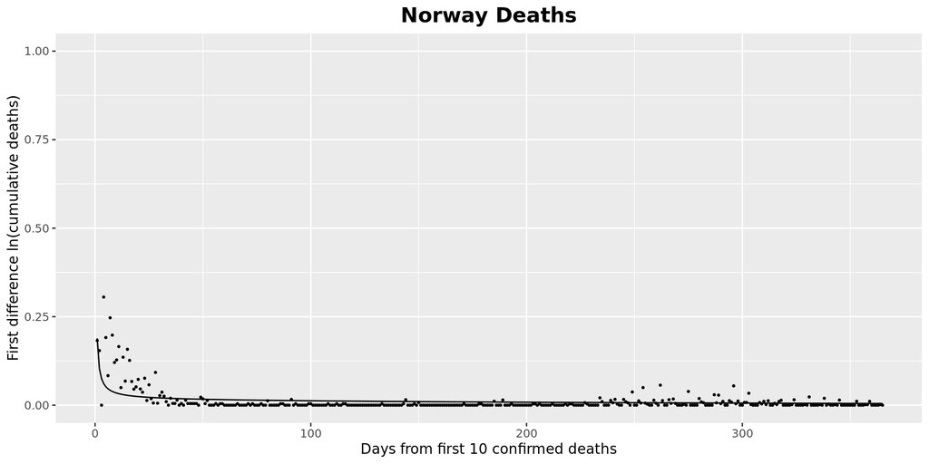

### Spain

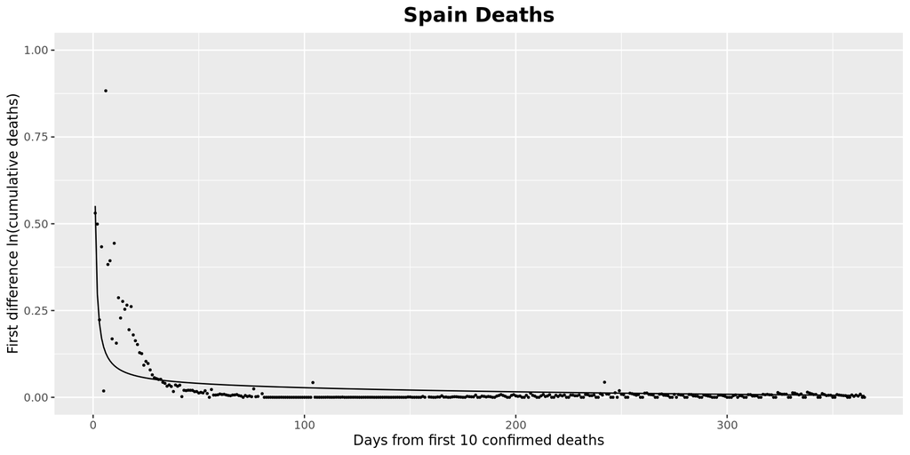

### Sweden

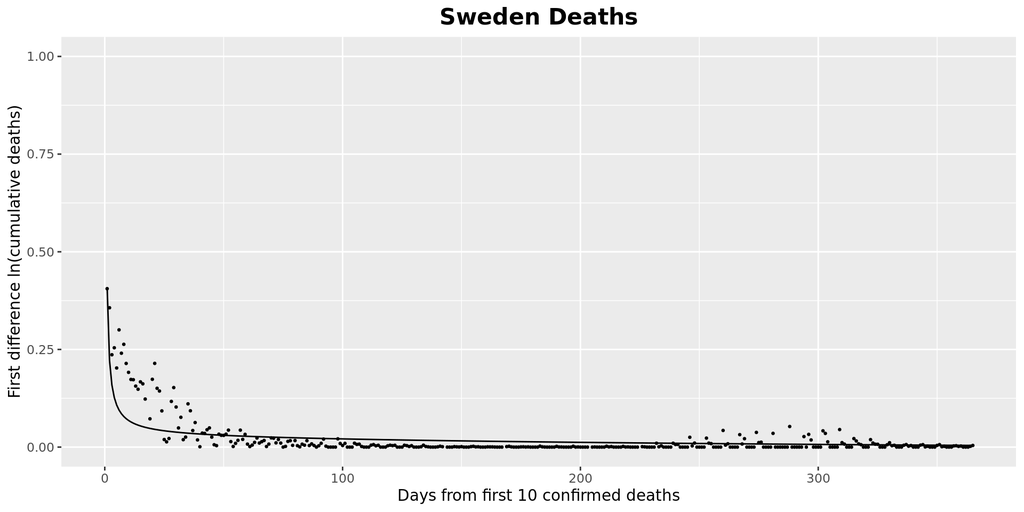

### Switzerland

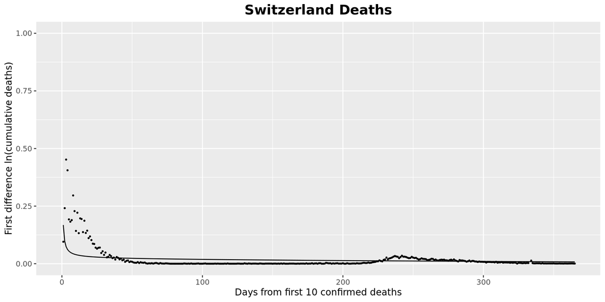

### United Kingdom

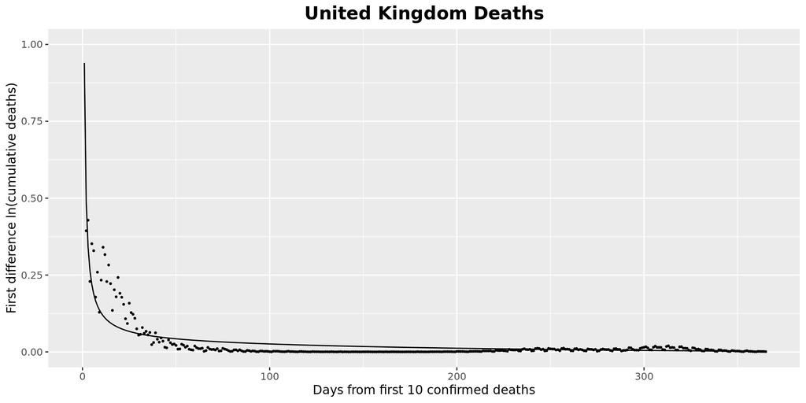

### United States

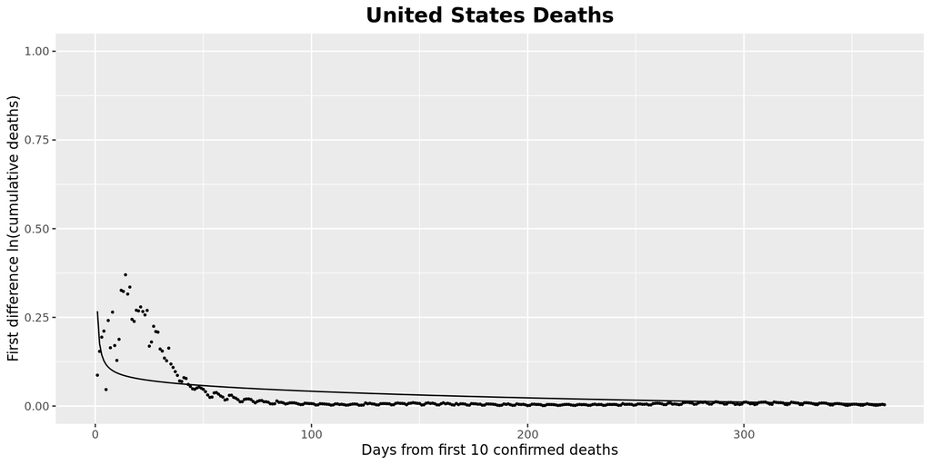

Back to top

# Calculating Deaths per 1% Increase in Unemployment

Using The Bureau of Labor statistics, there are 158.76 million workers in the U.S. and 1% of this is 1,587,600 (Feb 2019 data). The average death rate for 25-64 year olds = 402.625 per 100,000 (2017 CDC death data). Scaled up to 1,587,600 we get 6392 deaths per 1,587,600 people. Risk of death increases by 63% when you lose your job: https://www.ncbi.nlm.nih.gov/pmc/articles/PMC3070776/. Thus, this leads to 10,419.08 deaths or approximately 4,027 additional deaths per year per 1% increase in unemployment for working individuals (aged 25-64 years).

# Calculating Deaths per Million

The United States has a population of 327.2 million. The number of US cases as of August 01, 2022 is 91,472,835, and deaths 1,030,498. 1,030,498 deaths divided by 327.2 million = 0.0031494. Multiplied by one million and we get 3149.4 deaths per million. Compare to the number of deaths typically due to flu/pneumonia in the US of 170 deaths per million.  
The 1968 Hong Kong flu had a reported US death rate of 650 per million.  
The 1958 flu year was as high as 663 deaths per million.  
Neither epidemic led to any discussion of locking down the civilian population anywhere in the world. CDC’s weekly cumulative in-season estimates of flu cases, medical visits, hospitalizations and deaths in the United States: https://www.cdc.gov/flu/about/burden/preliminary-in-season-estimates.htm.

Back to top

# Mathematical Presentation of COVID-19 Transmission Dynamics

### Mathematical evidence that all susceptible patients were exposed by Day 1* of the epidemic in the United States and in approximately 80 other countries

*Day 1 is the first day that a given country has >100 cases or >10 deaths.

Current methods of detecting cases rely on the CDC 2019-Novel Coronavirus (2019-nCoV) Real-Time RT-PCR Diagnostic Panel, which is a real-time RT-PCR test intended for the detection of nucleic acid from the 2019-nCoV in the upper and lower respiratory tracts. Positive results are indicative of active infection with 2019-nCoV but do not rule out bacterial infection or co-infection with other viruses. Viral PCR panels can only tell us who is currently infected, and not who has already been exposed. (Reference: https://www.fda.gov/media/134922/download)

Serology testing for SARS-CoV-2 (aka 2019-nCoV, aka Covid-19, aka C19) is at increased demand in order to better quantify the number of cases of COVID-19, including those that may be asymptomatic or have recovered. Serology tests are blood-based tests that can be used to identify whether people have been exposed to a particular pathogen by looking at their immune response. In contrast, the RT-PCR tests currently being used globally to diagnose cases of COVID-19 can only indicate the presence of viral material during infection and will not indicate if a person was infected and subsequently recovered. These tests can give greater detail into the prevalence of a disease in a population by identifying individuals who have developed antibodies to the virus. Three serology tests have been FDA-approved thus far in April, 2020. (Reference: https://www.centerforhealthsecurity.org/resources/COVID-19/serology/Serology-based-tests-for-COVID-19.html)

On April 3, 2020, Stanford University began the first large-scale serological studies to test individuals for viral IgM and IgG antibodies. The presence of these antibodies indicates either that a person has active infection or has already been exposed and subsequently recovered. These tests are crucial for understanding the true levels of exposure to COVID-19 in the general population because they can tell us who has already been exposed to the virus. (Reference: https://www.stanforddaily.com/2020/04/04/stanford-researchers-test-3200-people-for-covid-19-antibodies/)

Numerous antibody test samples in Los Angeles County, Santa Clara County, pregnant women, Indiana and Ohio inmates, Chelsea Mass residents, Germany, Singapore and many other locations increasingly indicate that C19 was everywhere in the world months ago!

Finally, we note that COVID-caused deaths are subject to reporting biases. As of March 24, 2020, the CDC has issued guidance that any death can be coded as caused by COVID-19, even in the absence of confirmatory lab testing. In Italy, Professor Walter Ricciardi, scientific advisor to Italy’s minister of health, stated: “The way in which we code deaths in our country is very generous in the sense that all the people who die in hospitals with the coronavirus are deemed to be dying of the coronavirus… On re-evaluation by the National Institute of Health, only 12 per cent of death certificates have shown a direct causality from coronavirus, while 88 per cent of patients who have died have at least one pre-morbidity - many had two or three”. This implies that deaths in Italy are overreported by a factor of 8. (References: https://www.cdc.gov/nchs/data/nvss/coronavirus/Alert-2-New-ICD-code-introduced-for-COVID-19-deaths.pdf; https://www.telegraph.co.uk/global-health/science-and-disease/have-many-coronavirus-patients-died-italy/)

### Discrete Time:

Proof that the growth curve is logistic in discrete time.

The logistic growth rate can only be identically the same in multiple countries and regions (with different cultures, reporting patterns, test kit availability, social isolation controls, population density, population mixing, etc.) on every day of the epidemic (defined as Day 1 being the first day that a given country has >100 cases or >10 deaths) if the virus is already fully saturated in the susceptible population and only those unable to suppress the virus (because of underlying medical conditions or inadequate immune response) test positive at a constant rate regardless of testing volume. Under those conditions, the rate of positive detection is constant. The number of positive tests and deaths is ONLY a function of the number of tests administered in the population.

Let $r$ = rate of positive tests in the population.

Let $t_{i}$ = time of sampling.

Let $n_{i}$ = number of tests acquired in a country’s population at time $i$ (country index dropped without loss of generality).

Any sample $n_{i}$ at time $i$ will yield a rate of positive tests $r$.

Therefore:

$r * n_{i}$ = number of positives detected at time $i$

$n_{i} * (1-r)$ or $n_{i} – (r*n_{i})$ = number of negative tests.

Thus the ratio of positive to negative tests, or the ODDS of a positive test is:

$\displaystyle \frac{r*n_i}{n_i–(r*n_i)} = \displaystyle \frac{r}{1-r}$ = Constant $C$.

As you keep sampling, if the ratio is fixed, you get the summation of $\sum \frac{r}{1-r}$ over all times $t$. Then, log odds = constant $C$ (logistic growth).

If there is another growth model where $r$ is NOT constant then at each time $t_{i}$ there is an additional term, $\sum b_{i}*t_{i}$, where $b_{i}$ can change with every time point $t_{i}$.

Therefore we allow any possible set of time coefficients that can model any flexible growth model or decline model other than seroprevalence saturation.

Consider proof by contradiction:

Suppose, for contradiction that there is some time dependent growth (or decline) curve:

$\displaystyle \sum b_{i}*t_{i}$ over $i$ $(i = 1,2,…,K_{i})$,

where $b_{i}$ can change with every time point $t_i$. Let’s call that sum $A_i$, which can take any possible shape including positive at times and negative at times.

In order for $A_i$ to be consistent with the straight line logistic growth curve, it has to be the case that the new tests at time $i$ satisfy the following equation of motion:

$\displaystyle \frac{rN_i}{(1-r)N_i} + \frac{rN_i}{(1-r)N_i}A_i = r’$ for some $r’$ not equal to $r$ or 0.

This implies that, for all $i$:

$\displaystyle \frac{r}{(1-r)} + \displaystyle \frac{r}{(1-r)}A_i = r’$

$A_i = \displaystyle \frac{r’}{r}-r'-1 = C’$,

Consider the first observation:

$rb_1 = \displaystyle \frac{r’}{r} -r -1$

$b_1 = \displaystyle \frac{r’}{r^2} - 1 - \displaystyle \frac{1}{r} = C'$.

Consider the second observation:

$A_2 = b_1 + 2b_2 = \displaystyle \frac{r’}{r} - 1 - \displaystyle \frac{1}{r} = C’$

$A_2 = b_1 + b_2*2 = b_1 = C’$

$A_2 - b_1 = 2b_2 = 0 = C’$.

Then:

$A_j = C' + b_j*j = C’$.

Therefore $b_j = 0$ for all $j \ge 0$.

**Q.E.D.**

### Continuous time:

$ln$(first difference MA cases) = $r*ln$(MA cases)

(first difference MA cases) = $r’*$(MA cases)

(MA is Moving Average; Aatish used 7 days, we use 3 days).

Both imply that:

1. $\displaystyle \frac{dQ}{dt} = C*Q(t)$ for some estimable parameter $C$,

where $t$ is time and $Q(t)$ is the cumulative C19 cases reported at time $t$.

Let $dQ/dt$ = some general (smoothly continuous, twice differentiable, etc.) function of $Q(t)$ and $t$.

Consider the equation of motion:

$\displaystyle \frac{dQ}{dt} = G(Q,t) = G_1(Q(t),t) + G_2(Q(t),t)$,

where $G_1$ is only a function of $Q$ and represents the background baseline seroprevalence ($r$) in the population (e.g. United States) on Day One of the epidemic (3/3/2020 in the United States).

Then:

$\displaystyle \frac{d^2Q}{dt^2} = \displaystyle \frac{dG_1}{dt} + \displaystyle \frac{dG_2}{dt} = 0 + [\displaystyle \frac{∂G_2}{∂Q}] \displaystyle \frac{∂Q}{∂t} + \displaystyle \frac{∂G_2}{∂t}$.

From (1):

$\displaystyle \frac{d^2Q}{dt^2} = [\displaystyle \frac{∂G_2}{∂Q}](C*Q) + \displaystyle \frac{∂G_2}{∂t}$.

The first term is only a function of $Q$, not time. The second term is demonstrated to be zero empirically in Aatish’s curves.

Since there is no acceleration or deceleration in $dQ/dt$ over time:

$\displaystyle \frac{dQ}{dt} = C*Q = [\displaystyle \frac{∂G_2}{∂Q}](C*Q) = C''Q$ ,

where $C''$ is constant in $Q$, implying that seeing all countries on the same $dQ/dt$ curve is ONLY consistent with an epidemic that is neither growing nor declining with time.

**Q.E.D.**

Back to top

Data adapted from Johns Hopkins Unversity CSSE 2019 Novel Coronavirus COVID-19 (2019-nCoV) Data Repository: https://github.com/CSSEGISandData/COVID-19.

(All rights reserved, copyright pending.)